# Smartphone Addiction: Predictive Analytics and Behavioral Insights

A Logistic Modeling Study of Digital Usage, Lifestyle Patterns, and Academic Impact

Maurice Juma

May 06, 2026

```r
knitr::opts_chunk$set(echo = FALSE, warning = FALSE, message = FALSE, fig.align = "center", out.width = "100%")
```

# Executive Summary

## Key Findings

### Insight and Model Performance

#### Executive Insight

70.8%  
*of the population exhibits smartphone addiction*

This section presents the core analytical insights derived from behavioral patterns observed in the dataset.

#### Predictive Model Performance

- **Model Type:** Logistic Regression (GLM)
- **Accuracy:** 89%
- **AUC:** 0.95 (Excellent discrimination)
- **Sensitivity:** 94% (High detection of addicted individuals)
- **Specificity:** 78% (Strong identification of non-addicted individuals)

**Insight:** The model demonstrates high predictive power, confirming that behavioral patterns can reliably identify individuals at risk of smartphone addiction.

### Why It Matters

Smartphone addiction is not merely a usage issue—it is a **behavioral risk pattern** with measurable consequences on **performance, wellbeing, and long-term productivity**.

Without targeted intervention, these patterns are likely to **intensify over time**, particularly among younger, high-exposure populations.

## Strategic Implication

#### Action Priority

The highest-impact interventions should focus on:

- **Screen Time Regulation** (daily usage controls, digital limits)
- **Sleep Hygiene Improvement** (reducing late-night device exposure)

## Context and Objective

This analysis applies **predictive analytics** to assess the drivers and consequences of smartphone addiction across a sample of **7,500 individuals**, supported by a **logistic regression model (GLM)** used to classify and predict addiction risk.

The study focuses on translating behavioral data into **actionable insights**, enabling early identification of at-risk individuals and informing targeted interventions. The inclusion of a predictive model further strengthens the analysis by quantifying the probability of addiction based on observed behavioral patterns.

### Objective

To identify and quantify the **behavioral and lifestyle determinants** of smartphone addiction, to evaluate their impact on **academic performance and productivity outcomes**, and to develop a **reliable predictive model** capable of identifying individuals at risk based on key behavioral indicators.

## Population Profile

The dataset represents a **digitally engaged, youth-dominated population**, with a balanced gender distribution:

Participants are primarily concentrated in **early adulthood**, a segment characterized by:

- High exposure to digital environments
- Increased reliance on smartphones for communication and productivity
- Greater vulnerability to behavioral dependency patterns

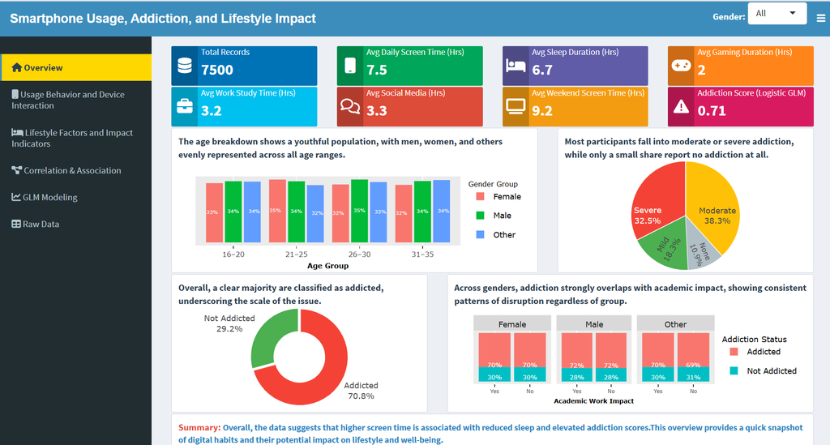

# Methodology

## Data Overview and Scope

The dataset contains **7,500 individual records**, each integrating demographic and behavioral information. This structure enables detailed, record-level analysis of smartphone usage patterns and their relationship to addiction outcomes.

#### Dataset Snapshot

A **synthetic dataset (7,500+ users)** linking user characteristics, digital behavior, and performance indicators to support predictive modeling of smartphone addiction while ensuring privacy and analytical flexibility.

## Variable Structure

The dataset variables are organized into three main categories:

- **Identifiers**  
  Unique user and transaction IDs for traceability
- **Demographic Variables**  
  Age and gender distribution, primarily concentrated in early adulthood

#### Behavioral Structure and Coverage

**Behavioral Variables**

- Daily screen time (hours)
- Social media usage (hours)
- Gaming activity (hours)
- Sleep duration (hours)
- Work/study time (hours)
- Weekend screen time (hours)

**Behavioral Coverage**

The dataset captures key dimensions of modern digital lifestyles:

- Screen time intensity
- Social media engagement
- Gaming behavior
- Sleep patterns
- Stress and productivity outcomes

These variables collectively represent the **behavioral drivers of smartphone addiction**.

## Observed Trends

#### Key Behavioral Patterns

- Average daily screen time is 7.5 hours, increasing to 9.2 hours on weekends
- Social media dominates usage at 3.3 hours per day on average
- Sleep duration averages 6.7 hours, below recommended health thresholds
- Gaming activity averages 2 hours, with significant variability across users

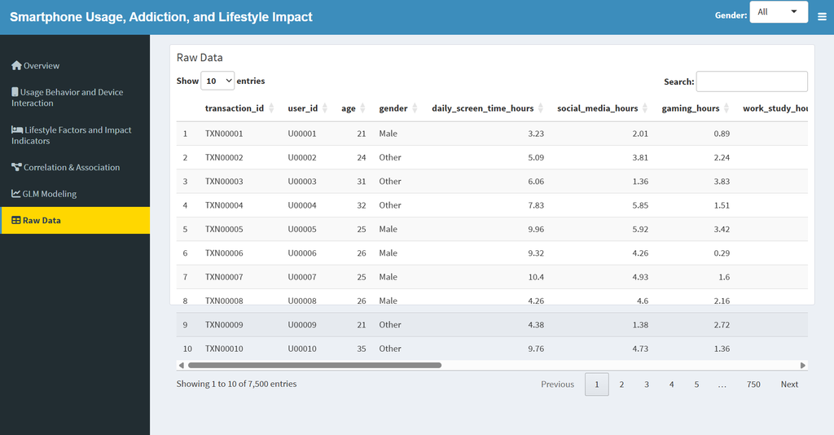

## Modeling Approach

To ensure robustness, model performance was evaluated using multiple metrics, including accuracy, sensitivity, specificity, and the Area Under the ROC Curve (AUC). The high AUC score confirms strong discriminative ability, while the balance between sensitivity and specificity ensures the model is suitable for both detection and screening purposes.

This multi-metric validation approach strengthens confidence in the model’s reliability and its applicability in real-world behavioral monitoring and intervention contexts.

## Significance

This overview underscores the diversity and intensity of digital engagement across the population. The interplay between screen time, social media usage, and sleep behavior provides a critical foundation for **predictive modeling of smartphone addiction**.

By integrating both behavioral and lifestyle indicators, the dataset enables:

- Robust identification of addiction risk factors
- Quantification of digital behavior trade-offs
- Deeper understanding of academic and productivity impacts

Importantly, the richness and variability of the dataset directly support the development of a **high-performing predictive model**. The logistic regression model, trained on these behavioral variables, achieved strong performance metrics—including high accuracy and an AUC of 0.95—demonstrating that the dataset contains sufficient signal to reliably distinguish between addicted and non-addicted individuals.

This confirms that smartphone addiction is not only observable but also **quantifiable and predictable** using behavioral data alone.

Ultimately, the dataset enables a transition from descriptive analysis to **predictive and prescriptive insight generation**. By capturing multiple dimensions of behavioral activity, the analysis supports not only the identification of risk factors, but also the implementation of **data-driven intervention strategies**, including early risk detection, behavioral monitoring, and targeted digital wellbeing programs.

## Limitations and Future Improvements

While the analysis provides strong evidence of behavioral drivers of smartphone addiction and demonstrates high predictive performance, several limitations should be acknowledged.

### Limitations

#### Limitations

1. **Synthetic Dataset Assumption**  
   The dataset used in this study is synthetic, which, while beneficial for privacy and controlled analysis, may not fully capture the complexity and variability of real-world behavioral patterns. As a result, model performance may differ when applied to real-world populations.
2. **Limited Variable Scope**  
   The model primarily relies on behavioral indicators such as screen time, social media usage, and sleep duration. However, smartphone addiction is also influenced by:
   - Psychological factors (e.g., stress, anxiety, self-control)
   - Environmental influences (e.g., peer behavior, academic pressure)
   - Socio-economic conditions

   The absence of these variables may limit the model’s ability to capture the full spectrum of addiction drivers.
3. **Cross-Sectional Data Structure**  
   The dataset represents a snapshot in time rather than longitudinal behavior. This limits the ability to:
   - Track behavioral changes over time
   - Establish causal relationships
   - Detect long-term addiction patterns
4. **Model Simplicity**  
   While logistic regression offers strong interpretability, it assumes linear relationships between predictors and the outcome. More complex, non-linear interactions between behavioral variables may not be fully captured.
5. **Classification Threshold Sensitivity**  
   The model uses a fixed classification threshold (e.g., 0.5), which may not be optimal for all contexts. Different thresholds could shift the balance between sensitivity and specificity depending on intervention priorities.

### Future Improvements

#### Future Improvements

1. **Incorporation of Additional Variables**  
   Future models should integrate psychological, behavioral, and environmental variables to improve predictive depth and explanatory power.
2. **Use of Real-World and Longitudinal Data**  
   Applying the model to real-world datasets and tracking users over time would enhance generalizability and enable causal analysis of addiction patterns.
3. **Advanced Modeling Techniques**  
   Exploring machine learning models such as:
   - Random Forest
   - Gradient Boosting (e.g., XGBoost)
   - Neural Networks

   could capture non-linear relationships and potentially improve predictive accuracy.
4. **Model Validation Enhancements**  
   Implementing techniques such as:
   - Train-test split
   - Cross-validation
   - Out-of-sample testing

   would further strengthen confidence in model robustness and reduce overfitting risk.
5. **Threshold Optimization**  
   Future work can explore dynamic threshold selection based on application context (e.g., prioritizing sensitivity for screening vs. specificity for precision targeting).

#### Forward-Looking Insight

Enhancing the model with richer data, advanced techniques, and stronger validation frameworks will enable the transition from predictive analytics to **intelligent, real-time digital wellbeing systems** capable of proactive intervention.

# Findings

## Digital Usage Patterns

#### Key Driver of Smartphone Addiction

The data shows that individuals classified as addicted consistently log higher daily and weekend screen time compared to non-addicted peers. This pattern suggests that smartphone use is not limited to weekday habits but extends into leisure periods, thereby reinforcing dependency cycles. The persistence of high screen exposure across both workdays and weekends highlights how digital engagement has become embedded in everyday routines, leaving little room for recovery or balance.

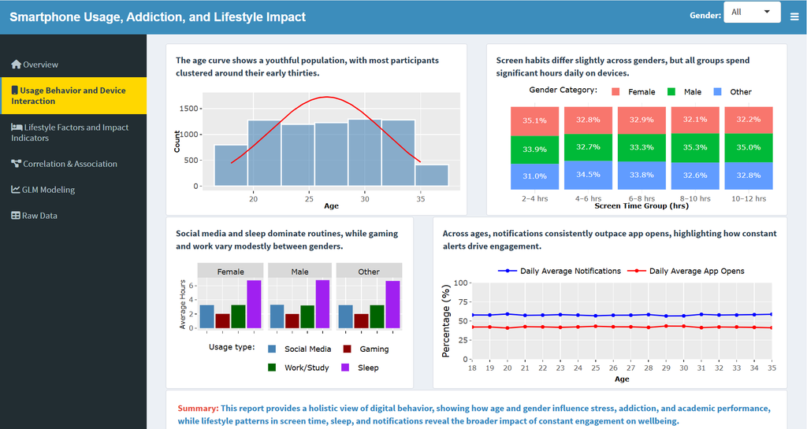

## Lifestyle Risk Factors

Together, these behaviors create a reinforcing feedback loop: reduced sleep increases stress and fatigue, which in turn drives greater reliance on digital devices for distraction or stimulation. This cycle highlights the dual role of sleep; both a protective factor and a casualty of smartphone addiction.

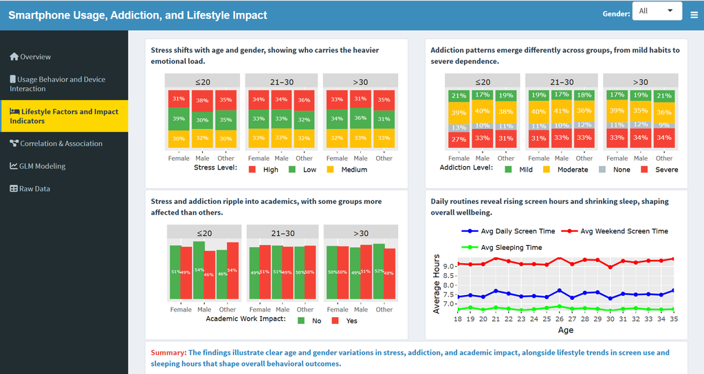

## Data Preview Reflection

#### Data Preview Reflection: Foundation for Predictive Modeling

The raw data preview provided a critical foundation for these insights. Examination of sample records revealed clear variability in screen time, social media usage, and sleep patterns across individuals. This variability is essential for distinguishing between addicted and non-addicted groups in predictive modeling.

The preview also highlighted the richness of the dataset, with multiple behavioral dimensions captured. This ensured that the analysis extends beyond a single factor, reflecting the complexity and interconnected nature of modern digital lifestyles.

#### Key Insight: Behavioral Dominance in Predicting Smartphone Addiction

**Behavioral variables significantly outperform demographic factors in predicting smartphone addiction.**

The logistic regression model confirms that behavioral variables — particularly daily screen time, social media use, and sleep duration — are far more predictive of addiction than demographic factors such as age or gender. This reinforces the interpretation that smartphone addiction is primarily a lifestyle-driven phenomenon.

The model’s strong accuracy and sensitivity further demonstrate that these behavioral markers can reliably identify at-risk individuals. This provides a robust foundation for predictive monitoring systems and early intervention strategies aimed at reducing addiction risk.

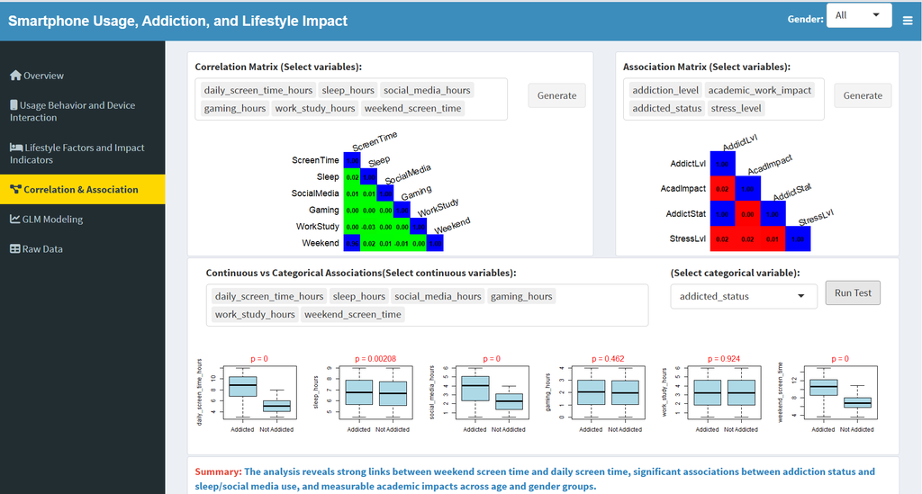

## Model Performance Evaluation

To assess the robustness and predictive accuracy of the logistic regression model, multiple evaluation metrics were applied. These include the **confusion matrix**, **Receiver Operating Characteristic (ROC) curve**, and **Area Under the Curve (AUC)**.

These metrics provide a comprehensive view of the model’s classification performance, balancing both sensitivity (true positive rate) and specificity (true negative rate).

### Confusion Matrix

Confusion Matrix (Predicted vs Actual Classification)

[output not shown]

#### Confusion Matrix Interpretation

The confusion matrix highlights the model’s strong classification performance across both classes.

- The model correctly identifies **94% of addicted individuals** (high sensitivity), indicating excellent detection capability for at-risk users.
- Only **6% of addicted individuals are misclassified**, minimizing the risk of overlooking critical cases.
- Among non-addicted individuals, **78% are correctly classified** (specificity), while **22% are incorrectly flagged as addicted**.

This distribution suggests that the model is slightly more aggressive in predicting addiction, favoring **early detection over strict precision**.

Such a trade-off is desirable in behavioral risk screening contexts, where the cost of missing an addicted individual (false negative) is significantly higher than incorrectly flagging a non-addicted individual (false positive).

#### Model Performance Insight

Overall, the model demonstrates a strong balance between detection and reliability, making it well-suited for **screening, monitoring, and early intervention applications**.

### ROC Curve

The Receiver Operating Characteristic (ROC) curve illustrates the trade-off between **sensitivity (true positive rate)** and **specificity (true negative rate)** across varying classification thresholds.

The **Area Under the Curve (AUC)** provides a single, comprehensive measure of the model’s ability to distinguish between addicted and non-addicted individuals.

#### Model Discrimination Performance

- **AUC: 0.95** → **Excellent classification performance**
- **Accuracy: 89%** → High overall prediction reliability

An AUC of **0.95** indicates that the model has an exceptional ability to correctly differentiate between addicted and non-addicted individuals. In practical terms, there is a 95% probability that the model will assign a higher risk score to an addicted individual than to a non-addicted individual.

This level of discrimination performance places the model in the **top tier of predictive accuracy**, confirming that the selected behavioral variables—such as screen time, social media usage, and sleep duration—are highly effective predictors of smartphone addiction.

The overall accuracy of **89%** further reinforces the model’s reliability, demonstrating strong alignment between predicted and actual classifications.

Together, these metrics confirm that the model is not only statistically robust but also **practically reliable for real-world application**, particularly in contexts requiring early detection, behavioral monitoring, and targeted intervention.

## Analytical Approach

A logistic regression model (Generalized Linear Model - GLM) was employed to predict smartphone addiction status based on key behavioral indicators derived from user activity patterns. The analytical framework is designed to classify users into addicted and non-addicted categories, and was selected due to its interpretability, robustness for binary outcomes, and suitability for behavioral datasets.

The model evaluates how variations in digital behavior influence the likelihood of addiction, enabling a clear quantification of risk factors and supporting a structured understanding of behavioral drivers.

#### Key Predictors of Smartphone Addiction

These predictors collectively represent core dimensions of digital engagement and lifestyle behavior that directly influence addiction probability.

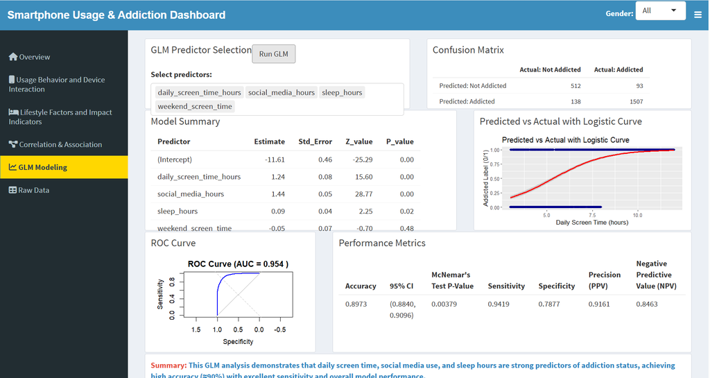

## Discussion

The findings provide compelling evidence that smartphone addiction is fundamentally a **behavior-driven phenomenon**, with lifestyle variables exerting significantly greater influence than demographic characteristics. This reinforces a critical shift in perspective—from identifying **who is at risk** to understanding **how risk is created and sustained through daily behavioral patterns**.

This behavioral dominance is further validated by the **logistic regression model**, which achieved an accuracy of **89%** and an AUC of **0.95**. These performance metrics confirm that behavioral indicators such as screen time, social media usage, and sleep duration are not only statistically significant but also **highly predictive in practical classification of addiction risk**.

Social media usage plays a particularly important role as an **intensity amplifier**. Unlike general screen time, social media introduces:

- Continuous notifications and interruptions
- Reward-driven engagement mechanisms
- Social validation and comparison loops

These features increase compulsive usage tendencies and reduce the likelihood of disengagement, making it a critical driver within the broader addiction system.

- Fragmented attention caused by frequent interruptions
- Reduced capacity for sustained deep work
- Inadequate cognitive recovery due to poor sleep quality

This explains why productivity declines even in cases where individuals maintain nominal study time.

Importantly, the weak influence of demographic variables highlights the **universality of the risk**. Smartphone addiction emerges as a cross-cutting behavioral issue affecting individuals regardless of age or gender. This has two major implications:

- Interventions should be **behavior-focused rather than demographic-specific**
- Solutions can be **scaled broadly across populations and institutions**

From an analytical standpoint, the model’s high sensitivity (**94%**) ensures that most addicted individuals are correctly identified, while a specificity of **78%** reflects a balanced ability to distinguish non-addicted users. This balance makes the model particularly suitable for **screening and early detection**, where minimizing missed risk cases is critical.

These results demonstrate that **behavioral data alone is sufficient for reliable prediction of addiction risk**, enabling the development of:

- Early warning systems based on usage patterns
- Real-time behavioral monitoring tools
- Targeted, personalized intervention strategies

#### Digital Wellbeing Intervention Priority

Smartphone addiction should be addressed as a **systemic lifestyle imbalance**, where digital consumption consistently exceeds recovery mechanisms such as sleep, rest, and focused activity.

The strong predictive performance of the model further supports the use of **data-driven intervention strategies**, enabling proactive identification and management of at-risk individuals.

Effective intervention must therefore prioritize restoring **behavioral balance**, not just reducing usage.

## Implications

#### Sectoral Implications

- → Public Health  
  Smartphone addiction represents a growing behavioral health concern, particularly among younger populations with high digital exposure.
- → Education Sector  
  Excessive digital use is contributing to declines in academic engagement, focus, and performance outcomes, necessitating targeted institutional responses.
- → Workplace and Policy  
  There is a clear need for structured digital wellbeing interventions aimed at reducing prolonged screen exposure and improving behavioral balance.

# Conclusion

This study confirms that smartphone addiction is a **predictable, measurable, and behaviorally driven phenomenon** with significant implications for individual wellbeing, productivity, and academic performance.

A critical contribution of this study is the demonstration that **behavioral variables alone are sufficient to accurately predict addiction risk**. The logistic regression model achieved an **accuracy of 89%** and an **AUC of 0.95**, indicating exceptional classification performance and strong real-world applicability. The model’s high sensitivity further ensures that the majority of at-risk individuals can be reliably identified.

These findings shift the focus of intervention from demographic targeting to **behavioral modification**, emphasizing the importance of managing daily digital habits rather than relying on population segmentation.

#### Strategic Intervention Priorities

- → Regulating screen time  
  Reduce excessive exposure to digital devices and promote healthier usage patterns.
- → Improving sleep hygiene  
  Restore cognitive and physical recovery through better rest and sleep practices.

#### Final Strategic Insight

Smartphone addiction should be addressed as a **behavioral system imbalance**, not merely a usage issue.

The combination of strong predictive modeling and behavioral insights provides a powerful foundation for **early detection, targeted intervention, and scalable digital wellbeing strategies**.

Ultimately, addressing smartphone addiction requires a coordinated approach that integrates **data-driven analytics, institutional policy, and individual behavioral change**.

By leveraging predictive models and focusing on modifiable lifestyle factors, organizations and individuals can move from reactive responses to **proactive prevention**, fostering healthier and more sustainable digital habits in an increasingly connected world.

# Recommendations

1. **Awareness Campaigns**  
   Promote responsible screen use and strengthen awareness of sleep hygiene and digital balance.
2. **Academic Interventions**  
   Introduce structured digital wellness programs within schools and universities to improve focus and learning outcomes.
3. **Policy Measures**  
   Implement guidelines that encourage controlled and intentional device usage in institutional environments.
4. **Further Research**  
   Extend predictive models to incorporate psychological, environmental, and socio-economic variables for deeper behavioral insights.
5. **Individual Strategies**  
   Encourage practical self-regulation approaches such as screen-time tracking, offline engagement, and device-free routines.